# Лабораторная работа №4

Основы администрирования операционных систем

Верниковская Е. А., НПИбд-01-23

Российский университет дружбы народов, Москва, Россия

21 сентября 2024

# Вводная часть

## Цель работы

Получить навыки работы с репозиториями и менеджерами пакетов.ы

## Задание

1. Изучить, как и в каких файлах подключаются репозитории для установки программного обеспечения; изучить основные возможности (поиск, установка, обновление, удаление пакета, работа с историей действий) команды dnf.
2. Изучить и повторить процесс установки/удаления определённого пакета с использованием возможностей dnf.
3. Изучить и повторить процесс установки/удаления определённого пакета с использованием возможностей rpm.

# Выполнение лабораторной работы

## Работа с репозиториями

В консоли переходим в режим работы суперпользователя, используя *su -* (рис. 1)

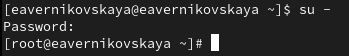

Режим суперпользователя

## Работа с репозиториями

Переходим в каталог /etc/yum.repos.d и смотрим содержание каталога (рис. 2)

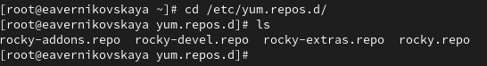

Содержимое каталога /etc/yum.repos.d

## Работа с репозиториями

Далее изучаем содержание файлов в этом каталоге, введя *cat название_репозитория.repo* (рис. 3), (рис. 4), (рис. 5), (рис. 6)

## Работа с репозиториями

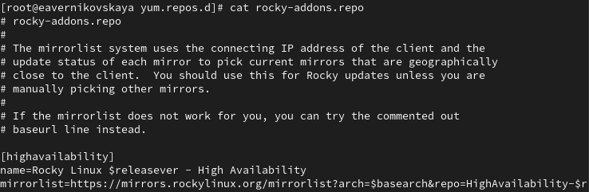

Содержание rocky-addons.repo

## Работа с репозиториями

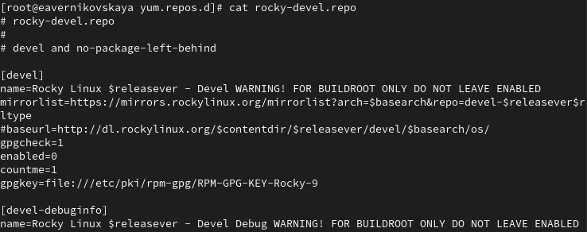

Содержание rocky-devel.repo

## Работа с репозиториями

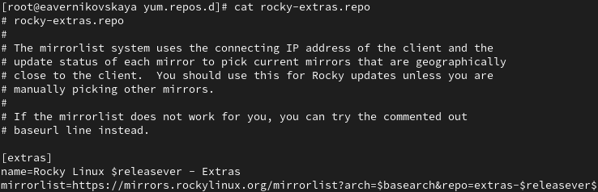

Содержание rocky-extars.repo

## Работа с репозиториями

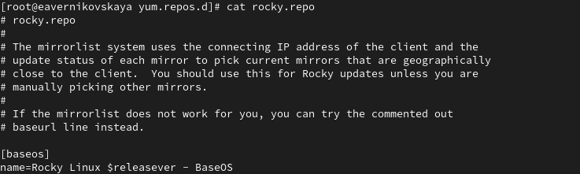

Содержание rocky.repo

## Работа с репозиториями

Выводим на экран список репозиториев: *dnf repolist*. Слева - id репозиториев, а справа - их названия (рис. 7)

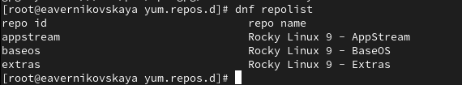

Список репозиториев

## Работа с репозиториями

Выодим на экран список пакетов, в названии или описании которых есть слово user: dnf search user (рис. 8)

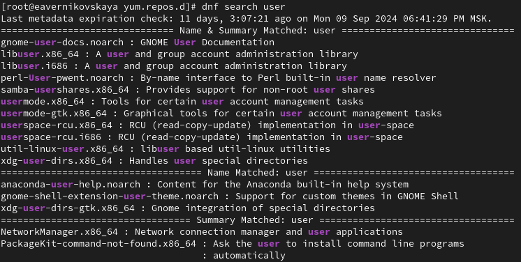

Список пакетов со словом user

## Работа с репозиториями

Далее устанавливаем nmap, предварительно изучив информацию по имеющимся пакетам: *dnf search nmap* *dnf info nmap* (рис. 9), (рис. 10)

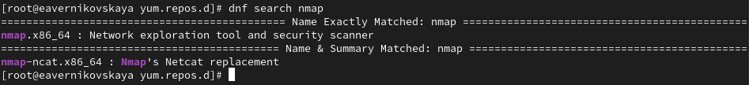

Работа команды dnf search nmap

## Работа с репозиториями

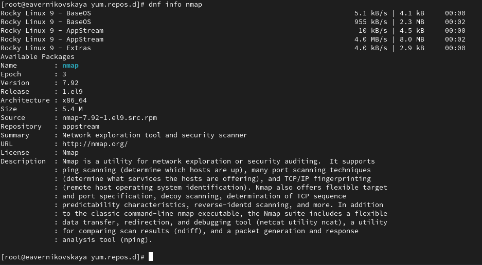

Работа команды dnf info nmap

## Работа с репозиториями

Устанавливаем nmap: *dnf install nmap* и dnf install nmap*. Первая команда устанавливает устанавливает только пакет с именем “nmap”, а вторая устанавливает все пакеты, чьи имена начинаются с “nmap” (рис. 11), (рис. 12)

## Работа с репозиториями

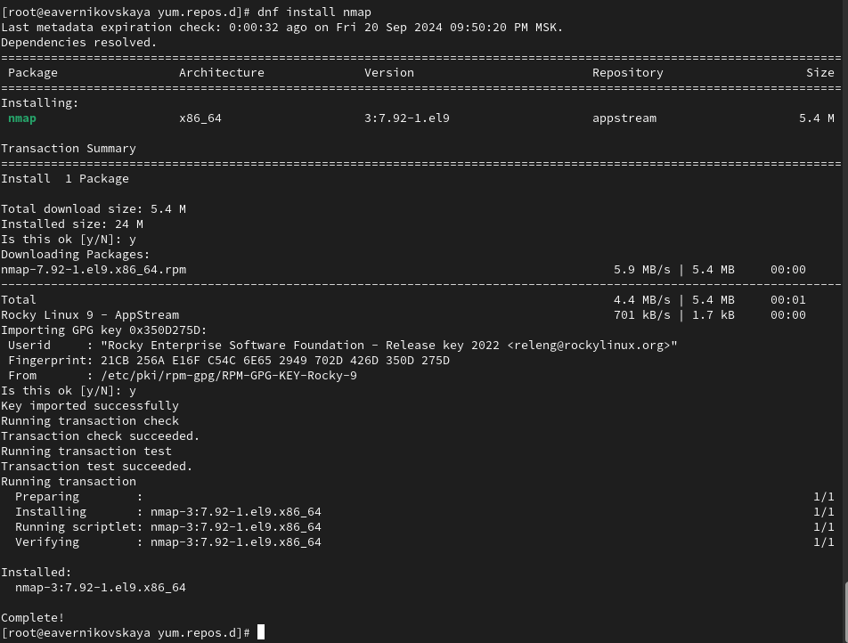

Установка пакета nmap

## Работа с репозиториями

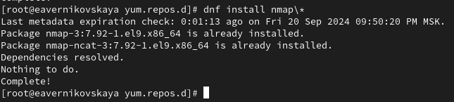

Установка всех пакетов с именем nmap

## Работа с репозиториями

Далее удаляем nmap (рис. 13), (рис. 14)

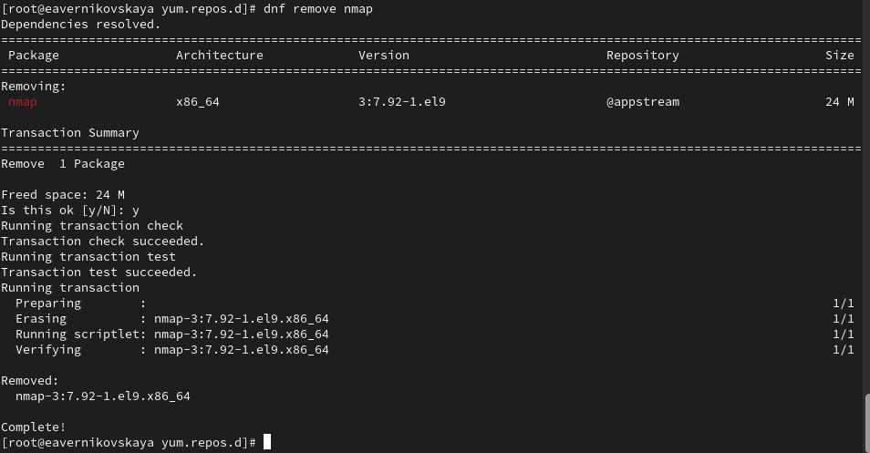

Удаление пакета nmap

## Работа с репозиториями

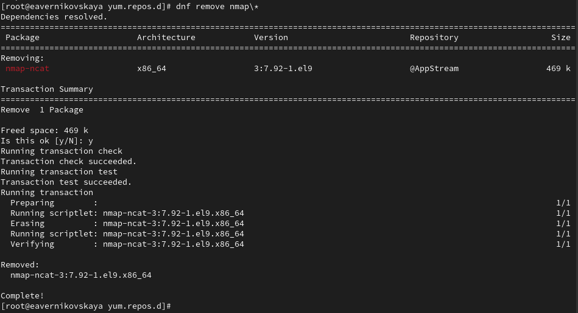

Удаление всех пакетов с именем nmap

## Работа с репозиториями

Далее получаем список имеющихся групп пакетов: *dnf groups list* и *LANG=C dnf groups list*. Вторая команда переводит вывод команды на английский язык независимо от установленного языка системы (рис. 15), (рис. 16)

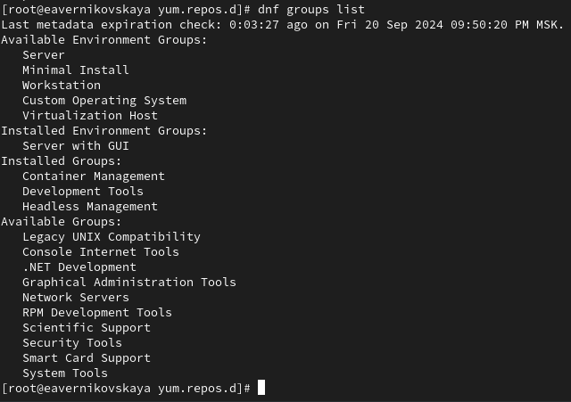

Работа команды dnf groups list

## Работа с репозиториями

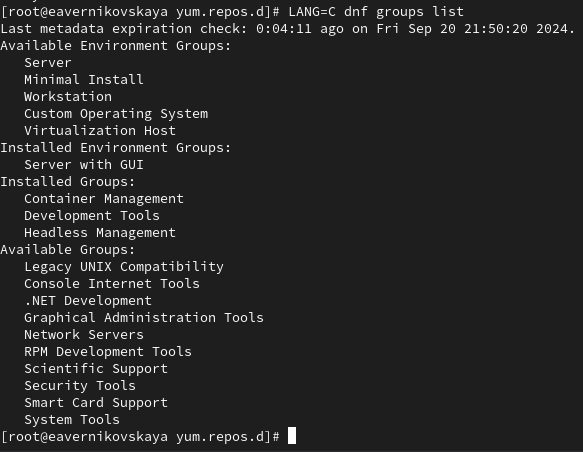

Работа команды LANG=C dnf groups list

## Работа с репозиториями

Далее выводим информацио о группе пакетов RPM Development Tools: *dnf groups info “RPM Development Tools”* (рис. 17)

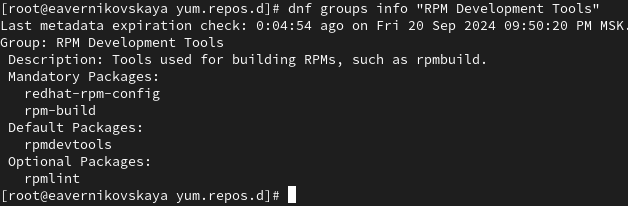

Информация о группе пакетов RPM Development Tools

## Работа с репозиториями

Устанавливаем эту группу пакетов: *dnf groupinstall “RPM Development Tools”* (рис. 18)

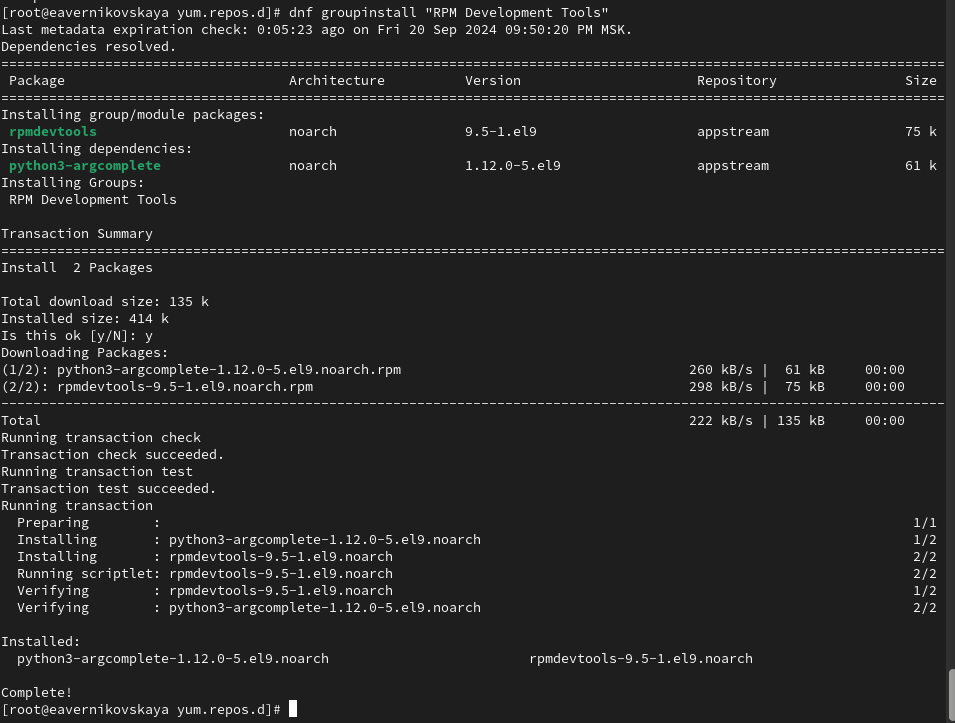

Установка RPM Development Tools

## Работа с репозиториями

Далее удаляем RPM Development Tools с помощью *dnf groupremove “RPM Development Tools”* (рис. 19)

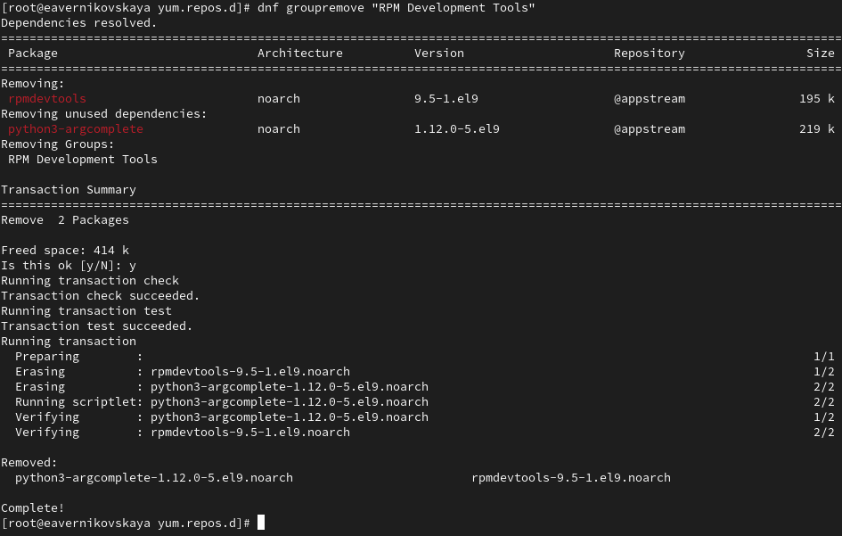

Удаление RPM Development Tools

## Работа с репозиториями

Смотрим историю использования команды dnf: *dnf history* (рис. 20)

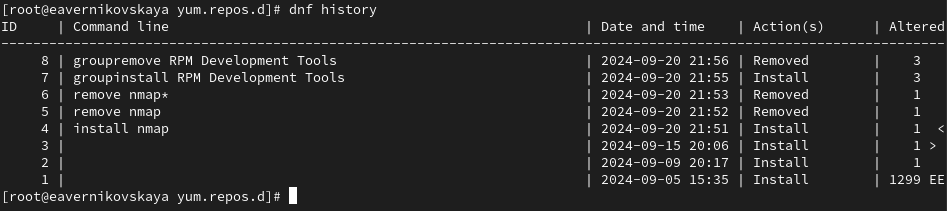

История использования команды dnf

## Работа с репозиториями

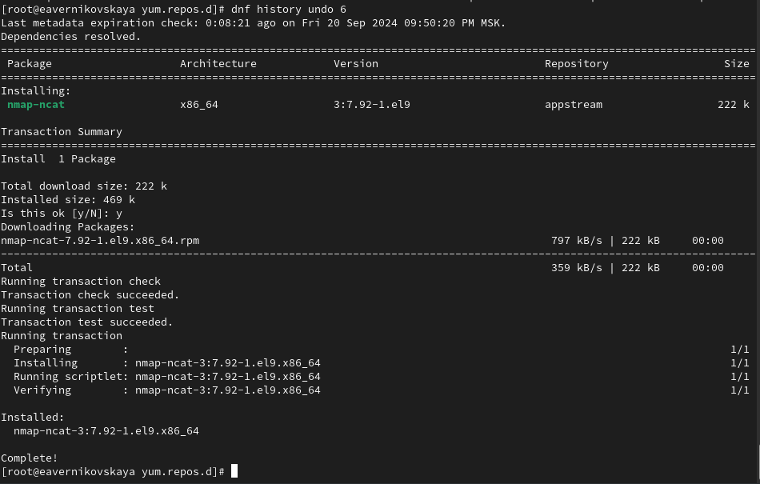

Отмена 6-ого действия

## Использование rpm

СКачиваем rpm-пакет lynx: *dnf install lynx –downloadonly*, перерд этим посмотрев список пакетов lynx: *dnf list lynx* (рис. 22), (рис. 23)

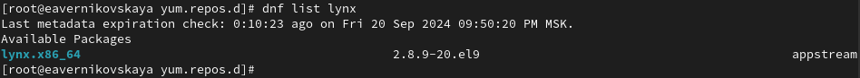

Список пакетов lynx

## Использование rpm

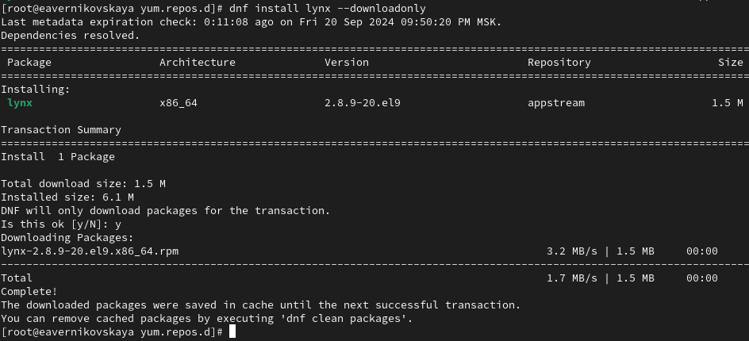

## Использование rpm

Находим каталог, в который был помещён пакет после загрузки (рис. 24)

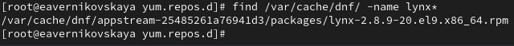

Каталог в который загрузился пакет

## Использование rpm

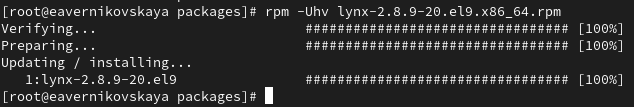

Установка rpm-пакета

## Использование rpm

Определяем расположение исполняемого файла: *which lynx* (рис. 27)

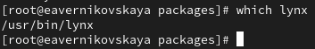

Расположение исполняемого файла (lynx)

## Использование rpm

Используя rpm, определяем по имени файла, к какому пакету принадлежит lynx: *rpm -qf $(which lynx)* (рис. 28)

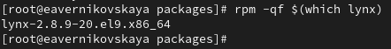

Пакет, к которому принадлежит lynx